This data tutorial provides an introduction to working with NEON eddy flux data, using the `neonUtilities` R package or the `neonutilities` Python package. If you are new to NEON data, we recommend starting with a more general tutorial, such as the [Download and Explore tutorial](https://www.neonscience.org/download-explore-neon-data). Some of the functions and techniques described there will be used here, as well as functions and data formats that are unique to the eddy flux system.

As of June 2026, NEON requires an API token for data downloads, to reduce bot scraping and improve user support. Tokens can be generated in NEON data portal user accounts - log in to your account or create one, and go to the API Tokens section. For best practices in storing and using tokens, follow the instructions [here](https://www.neonscience.org/resources/learning-hub/tutorials/api-token-setup).

This tutorial assumes general familiarity with eddy flux data and associated concepts.

## 1. Setup and data download

Start by installing and loading packages and setting options.

### R

To work with the NEON flux data, we need the `rhdf5` package, which is hosted on Bioconductor, and requires a different installation process than CRAN packages:

```r
install.packages('BiocManager')
BiocManager::install('rhdf5')
install.packages('neonUtilities')
install.packages('ggplot2')
```

Now load packages and API token.

```r
library(neonUtilities)
library(ggplot2)
token <- Sys.getenv("NEON_TOKEN")
```

### Python

The necessary helper packages should be installed automatically when we install `neonUtilities`. We’ll also use several modules that are installed automatically with standard Python installations.

```python
pip install neonutilities
```

Now load packages and token.

```python
import neonutilities as nu
import matplotlib.pyplot as plt
import pandas as pd
import numpy as np
from datetime import datetime
import dotenv
import os

dotenv.load_dotenv()
```

```python
token = os.environ.get("NEON_TOKEN")
```

### Download data

#### R

Use the `zipsByProduct()` function from the `neonUtilities` package to download flux data from two sites and two months. The transformations and functions below will work on any time range and site(s), but two sites and two months allows us to see all the available functionality while minimizing download size.

Inputs to the `zipsByProduct()` function for this tutorial:

- `dpID`: DP4.00200.001, the bundled eddy covariance product
- `package`: basic (the expanded package is not covered in this tutorial)
- `site`: NIWO = Niwot Ridge and HARV = Harvard Forest
- `startdate`: 2018-06 (both dates are inclusive)
- `enddate`: 2018-07 (both dates are inclusive)
- `savepath`: path to download to; here we use the working directory
- `check.size`: T if you want to see file size before downloading, otherwise F
- `token`: NEON API token

The download may take a while, especially if you’re on a slow network.

```r
zipsByProduct(dpID="DP4.00200.001", package="basic",
              site=c("NIWO", "HARV"),
              startdate="2018-06", enddate="2018-07",
              savepath=getwd(),
              check.size=F,
              token=token)
```

#### Python

Use the `zips_by_product()` function from the `neonutilities` package to download flux data from two sites and two months. The transformations and functions below will work on any time range and site(s), but two sites and two months allows us to see all the available functionality while minimizing download size.

Inputs to the `zips_by_product()` function for this tutorial:

- `dpid`: DP4.00200.001, the bundled eddy covariance product
- `package`: basic (the expanded package is not covered in this tutorial)
- `site`: NIWO = Niwot Ridge and HARV = Harvard Forest
- `startdate`: 2018-06 (both dates are inclusive)
- `enddate`: 2018-07 (both dates are inclusive)
- `savepath`: path to download to; here we use the working directory
- `check_size`: T if you want to see file size before downloading, otherwise F
- `token`: NEON API token

The download may take a while, especially if you’re on a slow network.

```python
nu.zips_by_product(dpid="DP4.00200.001", package="basic",
              site=["NIWO","HARV"],
              startdate="2018-06", enddate="2018-07",
              savepath=os.getcwd(),
              check_size=False,
              token=token)
```

## 2. Data Levels

There are five levels of data contained in the eddy flux bundle. For full details, refer to the [NEON algorithm document](http://data.neonscience.org/api/v0/documents/NEON.DOC.004571vA).

Briefly, the data levels are:

- Level 0’ (dp0p): Calibrated raw observations
- Level 1 (dp01): Time-aggregated observations, e.g. 30-minute mean gas concentrations
- Level 2 (dp02): Time-interpolated data, e.g. rate of change of a gas concentration
- Level 3 (dp03): Spatially interpolated data, i.e. vertical profiles
- Level 4 (dp04): Fluxes

The dp0p data are available in the expanded data package and are beyond the scope of this tutorial.

The dp02 and dp03 data are used in storage calculations, and the dp04 data include both the storage and turbulent components. Since many users will want to focus on the net flux data, we’ll start there.

## 3. Extract Level 4 data (Fluxes!)

### R

To extract the Level 4 data from the HDF5 files and merge them into a single table, we’ll use the `stackEddy()` function from the `neonUtilities` package.

`stackEddy()` requires two inputs:

- `filepath`: Path to a file or folder, which can be any one of:
  1. A zip file of eddy flux data downloaded from the NEON data portal
  2. A folder of eddy flux data downloaded by the `zipsByProduct()` function
  3. The folder of files resulting from unzipping either of 1 or 2
  4. One or more HDF5 files of NEON eddy flux data
- `level`: dp01-4

Input the filepath you downloaded to using `zipsByProduct()` earlier, including the `filestoStack00200` folder created by the function, and `dp04`:

```r
flux <- stackEddy(filepath=paste0(getwd(), "/filesToStack00200"),
                 level="dp04")
```

```
## Extracting data
```

```
## Joining data variables by file
```

```
## Stacking files by month
```

```
## Getting metadata tables
```

```r
names(flux)
```

```
## [1] "HARV"                        "NIWO"
## [3] "variables"                   "objDesc"
## [5] "issueLog"                    "citation_00200_RELEASE-2026"
```

Let’s look at the contents of one of the site data files:

```r
head(flux$NIWO)
```

```
##               timeBgn             timeEnd data.fluxCo2.nsae.flux
## 1 2018-06-01 00:00:00 2018-06-01 00:29:59              0.1895604
## 2 2018-06-01 00:30:00 2018-06-01 00:59:59              0.9429929
## 3 2018-06-01 01:00:00 2018-06-01 01:29:59              0.5101887
## 4 2018-06-01 01:30:00 2018-06-01 01:59:59              0.7980803
## 5 2018-06-01 02:00:00 2018-06-01 02:29:59              0.4345524
## 6 2018-06-01 02:30:00 2018-06-01 02:59:59              0.8440311
##   data.fluxCo2.stor.flux data.fluxCo2.turb.flux data.fluxH2o.nsae.flux
## 1            -0.06349451              0.2530549              16.428558
## 2             0.09749592              0.8454970               7.965026
## 3             0.02525844              0.4849303               5.387009
## 4             0.23341588              0.5646644               9.933795
## 5             0.17415575              0.2603966               2.963931
## 6            -0.01496958              0.8590007               4.488221
##   data.fluxH2o.stor.flux data.fluxH2o.turb.flux data.fluxMome.turb.veloFric
```

[output cut: 83 more lines]

The `variables` and `objDesc` tables can help you interpret the column headers in the data table. The `objDesc` table contains definitions for many of the terms used in the eddy flux data product, but it isn’t complete. To get the terms of interest, we’ll break up the column headers into individual terms and look for them in the `objDesc` table:

```r
term <- unlist(strsplit(names(flux$NIWO), split=".", fixed=T))
flux$objDesc[which(flux$objDesc$X...Object %in% term),]
```

```
##           X...Object
## 22       angZaxsErth
## 84              data
## 91          distReso
## 92        distXaxs90
## 93       distXaxsMax
## 94        distYaxs90
## 95       distZaxsAbl
## 100 distZaxsMeasDisp
## 101      distZaxsRgh
## 125             flux
## 126          fluxCo2
## 128          fluxH2o
## 130         fluxMome
## 132         fluxTemp
```

[output cut: 39 more lines]

For the terms that aren’t captured here, `fluxCo2`, `fluxH2o`, and `fluxTemp` are self-explanatory. The flux components are

- `turb`: Turbulent flux
- `stor`: Storage
- `nsae`: Net surface-atmosphere exchange

The `variables` table contains the units for each field:

```r
flux$variables
```

```
##    category   system variable             stat           units
## 1      data  fluxCo2     nsae          timeBgn              NA
## 2      data  fluxCo2     nsae          timeEnd              NA
## 3      data  fluxCo2     nsae             flux umolCo2 m-2 s-1
## 4      data  fluxCo2     stor          timeBgn              NA
## 5      data  fluxCo2     stor          timeEnd              NA
## 6      data  fluxCo2     stor             flux umolCo2 m-2 s-1
## 7      data  fluxCo2     turb          timeBgn              NA
## 8      data  fluxCo2     turb          timeEnd              NA
## 9      data  fluxCo2     turb             flux umolCo2 m-2 s-1
## 10     data  fluxH2o     nsae          timeBgn              NA
## 11     data  fluxH2o     nsae          timeEnd              NA
## 12     data  fluxH2o     nsae             flux           W m-2
## 13     data  fluxH2o     stor          timeBgn              NA
## 14     data  fluxH2o     stor          timeEnd              NA
```

[output cut: 64 more lines]

### Python

To extract the Level 4 data from the HDF5 files and merge them into a single table, we’ll use the `stack_eddy()` function from the `neonutilities` package.

`stack_eddy()` requires two inputs:

- `filepath`: Path to a file or folder, which can be any one of:
  1. A zip file of eddy flux data downloaded from the NEON data portal
  2. A folder of eddy flux data downloaded by the `zips_by_product()` function
  3. The folder of files resulting from unzipping either of 1 or 2
  4. One or more HDF5 files of NEON eddy flux data
- `level`: dp01-4

Input the filepath you downloaded to using `zips_by_product()` earlier, including the `filestoStack00200` folder created by the function, and `dp04`:

```python
flux = nu.stack_eddy(filepath=os.getcwd() + "/filesToStack00200",
                 level="dp04")
```

```python
flux.keys()
```

```
## dict_keys(['HARV', 'NIWO', 'variables', 'objDesc', 'issueLog', 'citation_00200_RELEASE-2026'])
```

Let’s look at the contents of one of the site data files:

```python
flux['NIWO'].head
```

```
## <bound method NDFrame.head of                        timeBgn  ... qfqm.foot.turb.qfFinl
## 0    2018-06-01 00:00:00+00:00  ...                     0
## 1    2018-06-01 00:30:00+00:00  ...                     0
## 2    2018-06-01 01:00:00+00:00  ...                     0
## 3    2018-06-01 01:30:00+00:00  ...                     0
## 4    2018-06-01 02:00:00+00:00  ...                     0
## ...                        ...  ...                   ...
## 2923 2018-07-31 21:30:00+00:00  ...                     0
## 2924 2018-07-31 22:00:00+00:00  ...                     0
## 2925 2018-07-31 22:30:00+00:00  ...                     0
## 2926 2018-07-31 23:00:00+00:00  ...                     0
## 2927 2018-07-31 23:30:00+00:00  ...                     0
##
## [2928 rows x 36 columns]>
```

The `variables` and `objDesc` tables can help you interpret the column headers in the data table. The `objDesc` table contains definitions for many of the terms used in the eddy flux data product, but it isn’t complete. To get the terms of interest, we’ll break up the column headers into individual terms and look for them in the `objDesc` table:

```python
termlist = [f.split('.') for f in flux['NIWO'].keys()]
term = [t for sublist in termlist for t in sublist]

objDesc = flux['objDesc']
objDesc[objDesc['Object'].isin(term)]
```

```
##                Object                                        Description
## 21        angZaxsErth                                     Wind direction
## 83               data                             Represents data fields
## 90           distReso      Resolution of vector of distances (units = m)
## 91         distXaxs90  Distance of 90% contriubtion of footprint alig...
## 92        distXaxsMax  Max distance of footprint contriubtion aligned...
## 93         distYaxs90  Distance of 90% contriubtion of footprint alig...
## 94        distZaxsAbl  Atmospheric boundary layer height used in flux...
## 99   distZaxsMeasDisp      Measurement height minus displacement height
## 100       distZaxsRgh  Roughness length used in flux footprint calcul...
## 124              flux                              General term for flux
## 125           fluxCo2      CO2 flux (can be turbulent, storage, or nsae)
## 127           fluxH2o  H2O flux (can be turbulent, storage, or nsae) ...
## 129          fluxMome  Momentum flux (can be turbulent, storage, or n...
## 131          fluxTemp  Temperature flux (can be turbulent, storage, o...
## 132              foot                                          Footprint
## 199              nsae  Net surface atmospher exchange (turbulent + st...
## 243            qfFinl  The final quality flag indicating if the data ...
## 273              qfqm  Quality flag and quality metrics, represents q...
## 450              stat                                         Statistics
## 452              stor                                            Storage
## 473           timeBgn       The beginning time of the aggregation period
## 474           timeEnd             The end time of the aggregation period
## 476              turb                                          Turbulent
## 504          veloFric            Friction velocity/ustar (units = m s-1)
## 511     veloYaxsHorSd  Standard deviation of horizontal wind speed in...
## 514     veloZaxsHorSd  Standard deviation of horizontal wind speed in...
```

For the terms that aren’t captured here, `fluxCo2`, `fluxH2o`, and `fluxTemp` are self-explanatory. The flux components are

- `turb`: Turbulent flux
- `stor`: Storage
- `nsae`: Net surface-atmosphere exchange

The `variables` table contains the units for each field:

```python
flux['variables']
```

```
##    category    system variable     stat            units
## 0      data   fluxCo2     nsae  timeBgn               NA
## 1      data   fluxCo2     nsae  timeEnd               NA
## 2      data   fluxCo2     nsae     flux  umolCo2 m-2 s-1
## 3      data   fluxCo2     stor  timeBgn               NA
## 4      data   fluxCo2     stor  timeEnd               NA
## ..      ...       ...      ...      ...              ...
## 73     qfqm  fluxTemp     turb  timeEnd               NA
## 74     qfqm  fluxTemp     turb   qfFinl               NA
## 75     qfqm      foot     turb  timeBgn               NA
## 76     qfqm      foot     turb  timeEnd               NA
## 77     qfqm      foot     turb   qfFinl               NA
##
## [78 rows x 5 columns]
```

### Plot fluxes

Let’s plot some data! First, a brief aside about time stamps, since these are time series data.

### Time stamps

NEON sensor data come with time stamps for both the start and end of the averaging period. Depending on the analysis you’re doing, you may want to use one or the other; for general plotting, re-formatting, and transformations, I prefer to use the start time, because there are some small inconsistencies between data products in a few of the end time stamps.

Note that **all** NEON data use UTC time, aka Greenwich Mean Time. This is true across NEON’s instrumented, observational, and airborne measurements. When working with NEON data, it’s best to keep everything in UTC as much as possible, otherwise it’s very easy to end up with data in mismatched times, which can cause insidious and hard-to-detect problems. In the code below, time stamps and time zones have been handled by `stackEddy()` and `loadByProduct()`, so we don’t need to do anything additional. But if you’re writing your own code and need to convert times, remember that if the time zone isn’t specified, R will default to the local time zone it detects on your operating system.

#### R

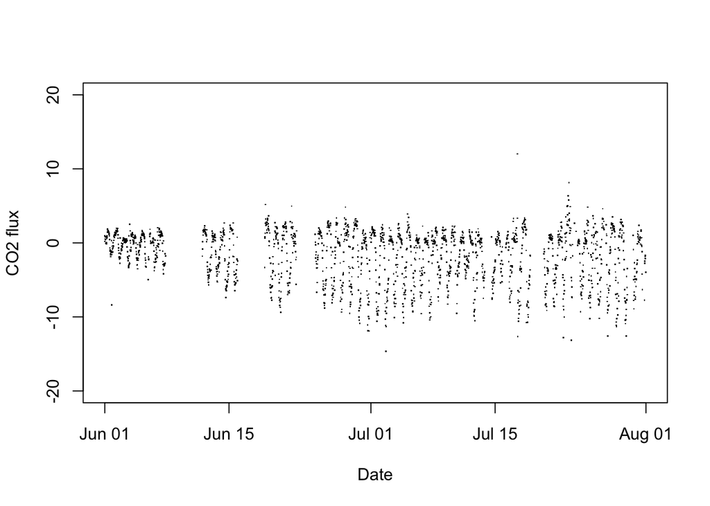

```r
plot(flux$NIWO$data.fluxCo2.nsae.flux~flux$NIWO$timeBgn,
     pch=".", xlab="Date", ylab="CO2 flux",
     ylim=c(-20,20))
```

There is a clear diurnal pattern, and an increase in daily carbon uptake as the growing season progresses.

Let’s trim down to just two days of data to see a few other details.

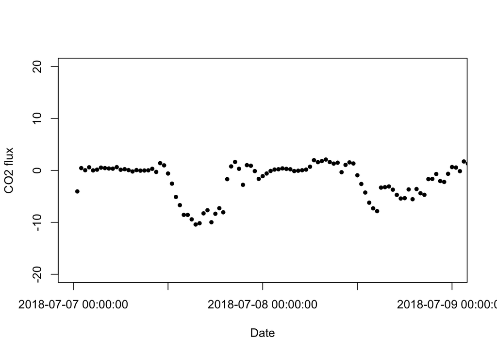

```r
plot(flux$NIWO$data.fluxCo2.nsae.flux~flux$NIWO$timeBgn,
     pch=20, xlab="Date", ylab="CO2 flux",
     xlim=c(as.POSIXct("2018-07-07", tz="GMT"),
            as.POSIXct("2018-07-09", tz="GMT")),
    ylim=c(-20,20), xaxt="n")
axis.POSIXct(1, x=flux$NIWO$timeBgn,
             format="%Y-%m-%d %H:%M:%S")
```

#### Python

```python
plt.scatter(flux['NIWO'].timeBgn,
            flux['NIWO']['data.fluxCo2.nsae.flux'],
           marker='.')
plt.ylim((-20,20))
```

```
## (-20.0, 20.0)
```

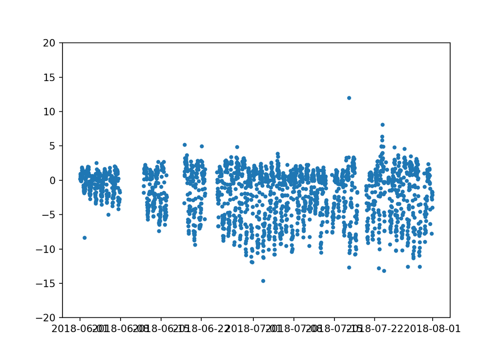

```python
plt.show()
```

There is a clear diurnal pattern, and an increase in daily carbon uptake as the growing season progresses.

Let’s trim down to just two days of data to see a few other details.

```python
plt.scatter(flux['NIWO'].timeBgn,
            flux['NIWO']['data.fluxCo2.nsae.flux'],
           marker='.')
plt.ylim((-20,20))
```

```
## (-20.0, 20.0)
```

```python
plt.xlim((datetime.strptime('2018-07-07 00:00:00', '%Y-%m-%d %H:%M:%S'),
          datetime.strptime('2018-07-09 00:00:00', '%Y-%m-%d %H:%M:%S')))
```

```
## (np.float64(17719.0), np.float64(17721.0))
```

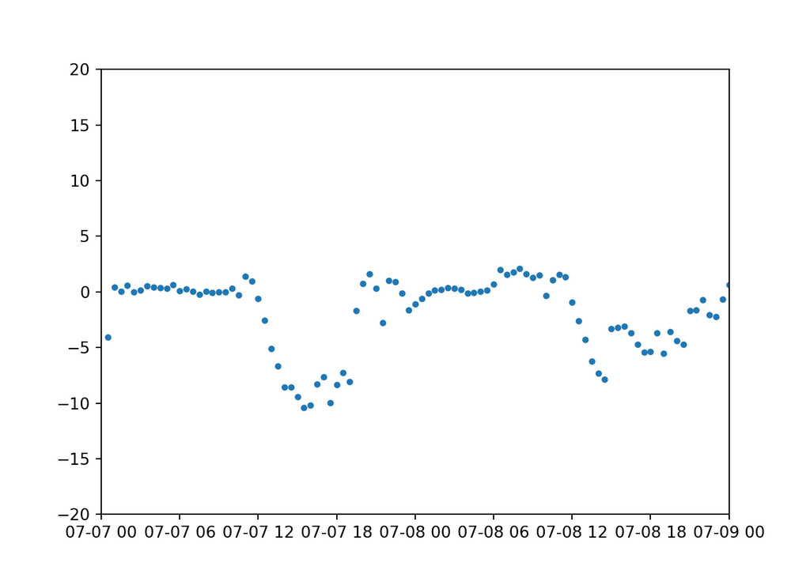

```python
plt.show()
```

Note the timing of C uptake; the UTC time zone is clear here, where uptake occurs at times that appear to be during the night.

## 4. Merge flux data with other sensor data

Many of the data sets we would use to interpret and model flux data are measured as part of the NEON project, but are not present in the eddy flux data product bundle. In this section, we’ll download PAR data and merge them with the flux data; the steps taken here can be applied to any of the NEON instrumented (IS) data products.

### Download PAR data

#### R

To get NEON PAR data, use the `loadByProduct()` function from the `neonUtilities` package. `loadByProduct()` takes the same inputs as `zipsByProduct()`, but it loads the downloaded data directly into the current R environment.

Let’s download PAR data matching the Niwot Ridge flux data. The inputs needed are:

- `dpID`: DP1.00024.001
- `site`: NIWO
- `startdate`: 2018-06
- `enddate`: 2018-07
- `package`: basic
- `timeIndex`: 30
- `token`: your API token

The new input here is `timeIndex=30`, which downloads only the 30-minute data. Since the flux data are at a 30-minute resolution, we can save on download time by disregarding the 1-minute data files (which are of course 30 times larger). The `timeIndex` input can be left off if you want to download all available averaging intervals.

```r
pr <- loadByProduct("DP1.00024.001", site="NIWO",
                    timeIndex=30, package="basic",
                    startdate="2018-06", enddate="2018-07",
                    check.size=F,
                    token=token)
```

#### Python

To get NEON PAR data, use the `load_by_product()` function from the `neonutilities` package. `load_by_product()` takes the same inputs as `zips_by_product()`, but it loads the downloaded data directly into the current Python environment.

Let’s download PAR data matching the Niwot Ridge flux data. The inputs needed are:

- `dpid`: DP1.00024.001
- `site`: NIWO
- `startdate`: 2018-06
- `enddate`: 2018-07
- `package`: basic
- `timeindex`: 30
- `token`: your API token

The new input here is `timeindex=30`, which downloads only the 30-minute data. Since the flux data are at a 30-minute resolution, we can save on download time by disregarding the 1-minute data files (which are of course 30 times larger). The `timeindex` input can be left off if you want to download all available averaging intervals.

```python
pr = nu.load_by_product("DP1.00024.001", site="NIWO",
                    timeindex=30, package="basic",
                    startdate="2018-06",
                    enddate="2018-07",
                    check_size=False,
                    token=token)
```

`pr` is another named list, and again, metadata and units can be found in the `variables` table. The `PARPAR_30min` table contains a `verticalPosition` field. This field indicates the position on the tower, with 010 being the first tower level, and 020, 030, etc going up the tower.

### Join PAR to flux data

We’ll connect PAR data from the tower top to the flux data.

#### R

```r
pr.top <- pr$PARPAR_30min[which(pr$PARPAR_30min$verticalPosition==
                                max(pr$PARPAR_30min$verticalPosition)),]
```

As noted above, `loadByProduct()` automatically converts time stamps to a recognized date-time format when it reads the data. However, the field names for the time stamps differ between the flux data and the other meteorological data: the start of the averaging interval is `timeBgn` in the flux data and `startDateTime` in the PAR data.

Let’s create a new variable in the PAR data:

```r
pr.top$timeBgn <- pr.top$startDateTime
```

And now use the matching time stamp fields to merge the flux and PAR data.

```r
fx.pr <- merge(pr.top, flux$NIWO, by="timeBgn")
```

And now we can plot net carbon exchange as a function of light availability:

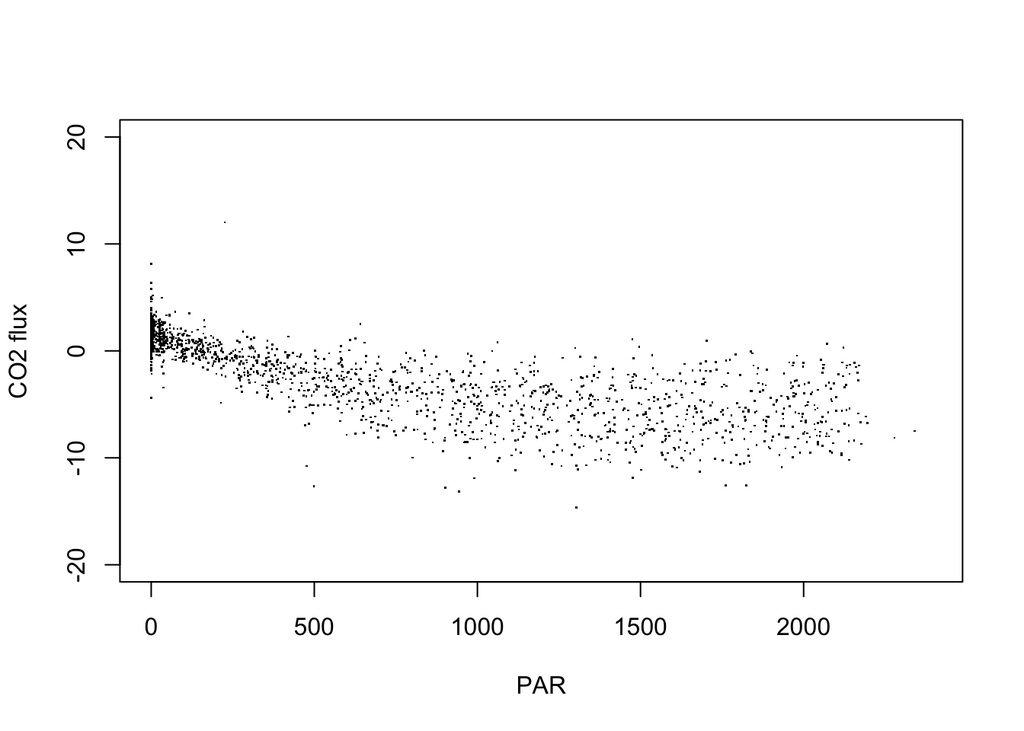

```r
plot(fx.pr$data.fluxCo2.nsae.flux~fx.pr$PARMean,
     pch=".", ylim=c(-20,20),
     xlab="PAR", ylab="CO2 flux")
```

#### Python

As noted above, `load_by_product()` automatically converts time stamps to a recognized date-time format when it reads the data. However, the field names for the time stamps differ between the flux data and the other meteorological data: the start of the averaging interval is `timeBgn` in the flux data and `startDateTime` in the PAR data.

Let’s create a new variable in the PAR data and subset to the top of the tower.

```python
par30 = pr['PARPAR_30min']
par30['timeBgn'] = par30['startDateTime']
prtop = par30[par30['verticalPosition']=='040']
```

And now use the matching time stamp fields to merge the flux and PAR data.

```python
fxpr = pd.merge(flux['NIWO'], prtop, how='outer', on='timeBgn')
```

And now we can plot net carbon exchange as a function of light availability:

```python
plt.scatter(fxpr.PARMean,
            fxpr['data.fluxCo2.nsae.flux'],
           marker='.')
plt.ylim((-20,20))
```

```
## (-20.0, 20.0)
```

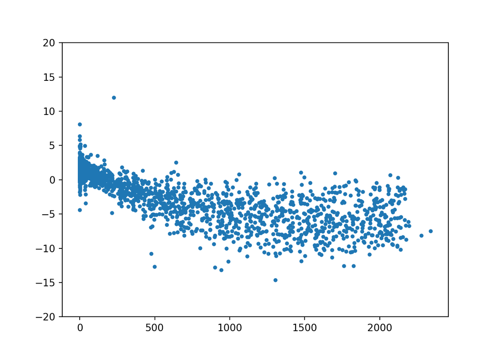

```python
plt.show()
```

If you’re interested in data in the eddy covariance bundle besides the net flux data, the rest of this tutorial will guide you through how to get those data out of the bundle.

## 5. Vertical profile data (Level 3)

The Level 3 (`dp03`) data are the spatially interpolated profiles of the rates of change of CO<sub>2</sub>, H<sub>2</sub>O, and temperature. Extract the Level 3 data from the HDF5 file using `stackEddy()` with the same syntax as for the Level 4 data.

### R

```r
prof <- stackEddy(filepath=paste0(getwd(), "/filesToStack00200"),
                 level="dp03")
```

As with the Level 4 data, the result is a named list with data tables for each site.

```r
head(prof$NIWO[,1:7])
```

```
##               timeBgn             timeEnd data.co2Stor.rateRtioMoleDryCo2.0.1 m
## 1 2018-06-01 00:00:00 2018-06-01 00:29:59                         -2.681938e-04
## 2 2018-06-01 00:30:00 2018-06-01 00:59:59                          1.912094e-05
## 3 2018-06-01 01:00:00 2018-06-01 01:29:59                          3.709964e-04
## 4 2018-06-01 01:30:00 2018-06-01 01:59:59                          2.374054e-03
## 5 2018-06-01 02:00:00 2018-06-01 02:29:59                          3.397046e-03
## 6 2018-06-01 02:30:00 2018-06-01 02:59:59                          3.156952e-03
##   data.co2Stor.rateRtioMoleDryCo2.0.2 m data.co2Stor.rateRtioMoleDryCo2.0.3 m
## 1                         -2.681938e-04                         -2.681938e-04
## 2                          1.912094e-05                          1.912094e-05
## 3                          3.709964e-04                          3.709964e-04
## 4                          2.374054e-03                          2.374054e-03
## 5                          3.397046e-03                          3.397046e-03
## 6                          3.156952e-03                          3.156952e-03
##   data.co2Stor.rateRtioMoleDryCo2.0.4 m data.co2Stor.rateRtioMoleDryCo2.0.5 m
## 1                         -2.681938e-04                         -2.681938e-04
## 2                          1.912094e-05                          1.912094e-05
## 3                          3.709964e-04                          3.709964e-04
## 4                          2.374054e-03                          2.374054e-03
## 5                          3.397046e-03                          3.397046e-03
## 6                          3.156952e-03                          3.156952e-03
```

### Python

Note (Feb 17, 2026): There is a bug in the Python implementation of the Level 3 code. This section may not run correctly, we will update as soon as possible.

```python
prof = nu.stack_eddy(filepath=os.getcwd() + "/filesToStack00200",
                 level="dp03")
```

As with the Level 4 data, the result is a named list with data tables for each site.

```python
prof['NIWO'].head()
```

## 6. Un-interpolated vertical profile data (Level 2)

The Level 2 data are interpolated in time but not in space. They contain the rates of change at each of the measurement heights.

### R

Again, they can be extracted from the HDF5 files using `stackEddy()` with the same syntax:

```r
prof.l2 <- stackEddy(filepath=paste0(getwd(), "/filesToStack00200"),
                 level="dp02")
```

```r
head(prof.l2$HARV)
```

```
##   horizontalPosition verticalPosition             timeBgn             timeEnd
## 1                000              010 2018-06-01 00:00:00 2018-06-01 00:29:59
## 2                000              010 2018-06-01 00:30:00 2018-06-01 00:59:59
## 3                000              010 2018-06-01 01:00:00 2018-06-01 01:29:59
## 4                000              010 2018-06-01 01:30:00 2018-06-01 01:59:59
## 5                000              010 2018-06-01 02:00:00 2018-06-01 02:29:59
## 6                000              010 2018-06-01 02:30:00 2018-06-01 02:59:59
##   data.co2Stor.rateRtioMoleDryCo2.mean data.h2oStor.rateRtioMoleDryH2o.mean
## 1                                  NaN                                  NaN
## 2                          0.002666576                                  NaN
## 3                         -0.011224223                                  NaN
## 4                          0.006133056                                  NaN
## 5                         -0.019554655                                  NaN
## 6                         -0.007855632                                  NaN
##   data.tempStor.rateTemp.mean qfqm.co2Stor.rateRtioMoleDryCo2.qfFinl
## 1                2.583333e-05                                      1
## 2               -2.008056e-04                                      1
## 3               -1.901111e-04                                      1
## 4               -7.419444e-05                                      1
## 5               -1.537083e-04                                      1
## 6               -1.874861e-04                                      1
##   qfqm.h2oStor.rateRtioMoleDryH2o.qfFinl qfqm.tempStor.rateTemp.qfFinl
## 1                                      1                             0
## 2                                      1                             0
## 3                                      1                             0
## 4                                      1                             0
## 5                                      1                             0
## 6                                      1                             0
```

### Python

Again, they can be extracted from the HDF5 files using `stackeddy()` with the same syntax:

```python
profl2 = nu.stack_eddy(filepath=os.getcwd() + "/filesToStack00200",
                 level="dp02")
```

```python
profl2['HARV'].head()
```

```
##   horizontalPosition  ... qfqm.tempStor.rateTemp.qfFinl
## 0                000  ...                             0
## 1                000  ...                             0
## 2                000  ...                             0
## 3                000  ...                             0
## 4                000  ...                             0
##
## [5 rows x 10 columns]
```

Note that here, as in the PAR data, there is a `verticalPosition` field. It has the same meaning as in the PAR data, indicating the tower level of the measurement.

## 7. Calibrated raw data (Level 1)

Level 1 (`dp01`) data are calibrated, and aggregated in time, but otherwise untransformed. Use Level 1 data for raw gas concentrations and atmospheric stable isotopes.

### Extract Level 1 data

#### R

Using `stackEddy()` to extract Level 1 data requires additional inputs. The Level 1 files are too large to simply pull out all the variables by default, and they include multiple averaging intervals, which can’t be merged. So two additional inputs are needed:

- `avg`: The averaging interval to extract
- `var`: One or more variables to extract

What variables are available, at what averaging intervals? Another function in the `neonUtilities` package, `getVarsEddy()`, returns a list of HDF5 file contents. It requires only one input, a filepath to a single NEON HDF5 file:

```r
vars <- getVarsEddy(paste0(getwd(),
                           "/filesToStack00200/NEON.D01.HARV.DP4.00200.001.nsae.2018-07.basic.20260115T064348Z.h5"))
head(vars)
```

```
##    site level category system hor ver tmi subsys       name       otype
## 5  HARV  dp01     data   amrs 000 060 01m   <NA> angNedXaxs H5I_DATASET
## 6  HARV  dp01     data   amrs 000 060 01m   <NA> angNedYaxs H5I_DATASET
## 7  HARV  dp01     data   amrs 000 060 01m   <NA> angNedZaxs H5I_DATASET
## 9  HARV  dp01     data   amrs 000 060 30m   <NA> angNedXaxs H5I_DATASET
## 10 HARV  dp01     data   amrs 000 060 30m   <NA> angNedYaxs H5I_DATASET
## 11 HARV  dp01     data   amrs 000 060 30m   <NA> angNedZaxs H5I_DATASET
##      dclass   dim  oth
## 5  COMPOUND 44640 <NA>
## 6  COMPOUND 44640 <NA>
## 7  COMPOUND 44640 <NA>
## 9  COMPOUND  1488 <NA>
## 10 COMPOUND  1488 <NA>
## 11 COMPOUND  1488 <NA>
```

Inputs to `var` can be any values from the `name` field in the table returned by `getVarsEddy()`. Let’s take a look at CO<sub>2</sub> and H<sub>2</sub>O, <sup>13</sup>C in CO<sub>2</sub> and <sup>18</sup>O in H<sub>2</sub>O, at 30-minute aggregation. Let’s look at Harvard Forest for these data, since deeper canopies generally have more interesting profiles:

```r
iso <- stackEddy(filepath=paste0(getwd(), "/filesToStack00200"),
               level="dp01", var=c("rtioMoleDryCo2","rtioMoleDryH2o",
                                   "dlta13CCo2","dlta18OH2o"), avg=30)
```

```r
head(iso$HARV[,1:8])
```

```
##   horizontalPosition verticalPosition             timeBgn             timeEnd
## 1                000              010 2018-06-01 00:00:00 2018-06-01 00:29:59
## 2                000              010 2018-06-01 00:30:00 2018-06-01 00:59:59
## 3                000              010 2018-06-01 01:00:00 2018-06-01 01:29:59
## 4                000              010 2018-06-01 01:30:00 2018-06-01 01:59:59
## 5                000              010 2018-06-01 02:00:00 2018-06-01 02:29:59
## 6                000              010 2018-06-01 02:30:00 2018-06-01 02:59:59
##   data.co2Stor.rtioMoleDryCo2.mean data.co2Stor.rtioMoleDryCo2.min
## 1                         509.3375                        451.4786
## 2                         502.2736                        463.5470
## 3                         521.6139                        442.8649
## 4                         469.6317                        432.6588
## 5                         484.7725                        436.2842
## 6                         476.8554                        443.7055
##   data.co2Stor.rtioMoleDryCo2.max data.co2Stor.rtioMoleDryCo2.vari
## 1                        579.3518                         845.0795
## 2                        533.6622                         161.3652
## 3                        563.0518                         547.9924
## 4                        508.7463                         396.8379
## 5                        537.4641                         662.9449
## 6                        515.6598                         246.6969
```

#### Python

Using `stack_eddy()` to extract Level 1 data requires additional inputs. The Level 1 files are too large to simply pull out all the variables by default, and they include multiple averaging intervals, which can’t be merged. So two additional inputs are needed:

- `avg`: The averaging interval to extract
- `var`: One or more variables to extract

Inputs to `var` can be any values from the `name` field in the table returned by `get_vars_eddy()`. Let’s take a look at CO<sub>2</sub> and H<sub>2</sub>O, <sup>13</sup>C in CO<sub>2</sub> and <sup>18</sup>O in H<sub>2</sub>O, at 30-minute aggregation. Let’s look at Harvard Forest for these data, since deeper canopies generally have more interesting profiles:

```python
iso = nu.stack_eddy(filepath=os.getcwd() + "/filesToStack00200",
                 level="dp01", avg=30,
                    var=["rtioMoleDryCo2","rtioMoleDryH2o",
                          "dlta13CCo2","dlta18OH2o"])
```

```python
iso['HARV'].head()
```

```
##   horizontalPosition  ... ucrt.h2oTurb.rtioMoleDryH2o.se
## 0                000  ...                            NaN
## 1                000  ...                            NaN
## 2                000  ...                            NaN
## 3                000  ...                            NaN
## 4                000  ...                            NaN
##
## [5 rows x 85 columns]
```

### Plot vertical profiles

Let’s plot vertical profiles of CO<sub>2</sub> and <sup>13</sup>C in CO<sub>2</sub> on a single day.

Here we’ll use the time stamps to select all of the records for a single day. And discard the `verticalPosition` values that are string values - those are the calibration gases.

#### R

```r
iso.d <- iso$HARV[grep("2018-06-25", iso$HARV$timeBgn, fixed=T),]
iso.d <- iso.d[-which(is.na(as.numeric(iso.d$verticalPosition))),]
```

`ggplot` is well suited to these types of data. We can plot CO<sub>2</sub> relative to height on the tower, with separate lines for each time interval.

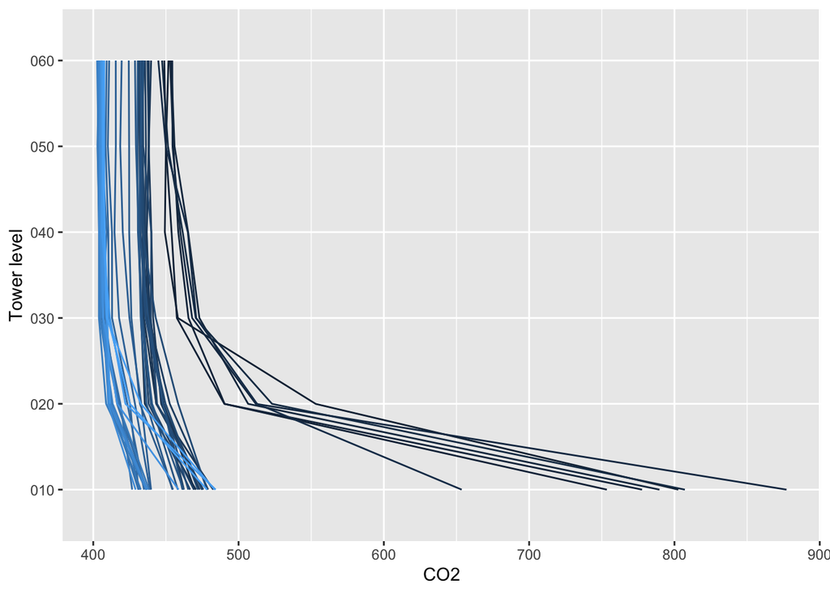

```r
g <- ggplot(iso.d, aes(y=verticalPosition)) +
  geom_path(aes(x=data.co2Stor.rtioMoleDryCo2.mean,
                group=timeBgn, col=timeBgn)) +
  theme(legend.position="none") +
  xlab("CO2") + ylab("Tower level")
g
```

And the same plot for <sup>13</sup>C in CO<sub>2</sub>:

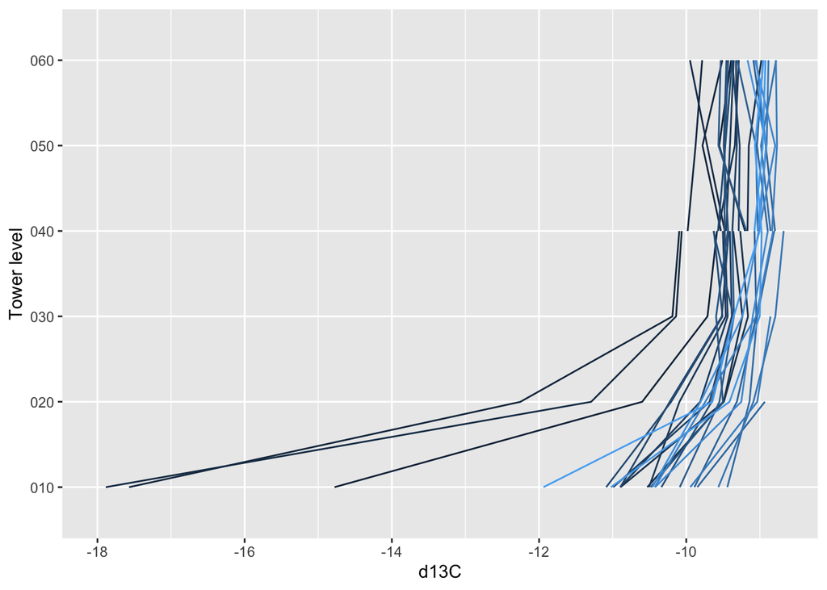

```r
g <- ggplot(iso.d, aes(y=verticalPosition)) +
  geom_path(aes(x=data.isoCo2.dlta13CCo2.mean,
                group=timeBgn, col=timeBgn)) +
  theme(legend.position="none") +
  xlab("d13C") + ylab("Tower level")
g
```

#### Python

```python
isoH = iso['HARV']
isoH6 = isoH[(isoH['timeBgn'] >= '2018-06-25') & (isoH['timeBgn'] < '2018-06-26')]
isod = isoH6[isoH6['horizontalPosition'] == '000']
```

Let’s plot CO<sub>2</sub> relative to height on the tower, with separate lines for each time interval.

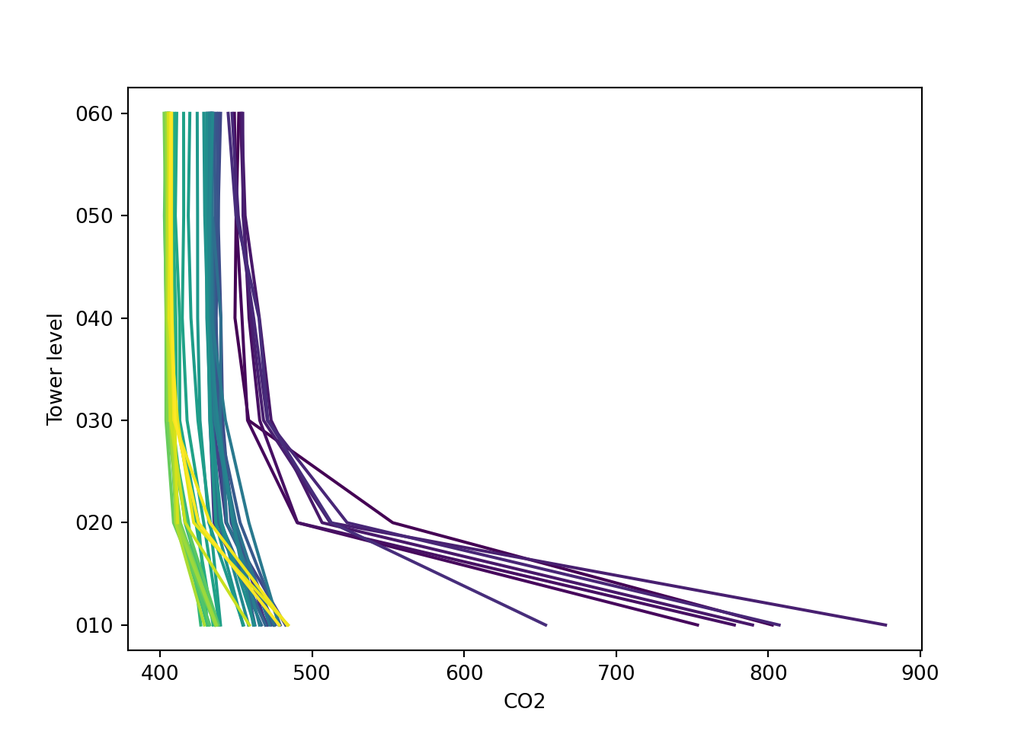

```python
fig, ax = plt.subplots()

groups = isod["timeBgn"].unique()

cmap = plt.cm.viridis
colors = cmap(np.linspace(0, 1, len(groups)))

for color, group_name in zip(colors, groups):
  group = isod[isod["timeBgn"] == group_name]
  ax.plot(group['data.co2Stor.rtioMoleDryCo2.mean'],
          group['verticalPosition'],
          color=color)

ax.set_xlabel("CO2")
ax.set_ylabel("Tower level")

plt.show()
```

And the same plot for <sup>13</sup>C in CO<sub>2</sub>:

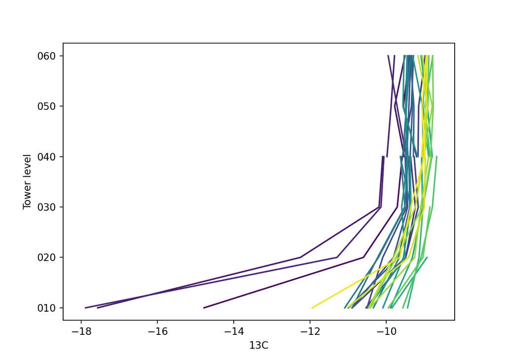

```python
fig, ax = plt.subplots()

for color, group_name in zip(colors, groups):
  group = isod[isod["timeBgn"] == group_name]
  ax.plot(group["data.isoCo2.dlta13CCo2.mean"],
          group["verticalPosition"],
          color=color)

ax.set_xlabel("13C")
ax.set_ylabel("Tower level")

plt.show()
```

The legends are omitted for space, see if you can use the concentration and isotope ratio buildup and drawdown below the canopy to work out the times of day the different colors represent.